# [SLCU R Course](https://tavareshugo.github.io/slcu_r_course/)

## Data manipulation with R - material

In this module we are going to see how to manipulate, subset and modify tables using `dplyr`, which is also a part of the `tidyverse` package family.

We will learn how to:

- select columns in a table
- filter a table based on certain conditions
- combine data manipulation and plotting
- summarise data across groups

First let’s load the `tidyverse` package and read the data that we will work on:

```r
library(tidyverse)

# Read data using read_csv
expt1 <- read_csv("../data/burghardt_et_al_2015_expt1.csv")
```

### Selecting columns with `select()`

To get an idea of data contents we will first check number of dimentsions with `dim()` and look at the column names with `names()`.

```r
dim(expt1)
```

```
## [1] 957  15
```

```r
names(expt1)
```

```
##  [1] "genotype"             "background"           "temperature"
##  [4] "fluctuation"          "day.length"           "vernalization"
##  [7] "survival.bolt"        "bolt"                 "days.to.bolt"
## [10] "days.to.flower"       "rosette.leaf.num"     "cauline.leaf.num"
## [13] "blade.length.mm"      "total.leaf.length.mm" "blade.ratio"
```

This is quite a large dataset, we don’t want to look at it all at once. Say, we are interested in just 2 columns for now: `genotype` and `temperature`.

To select the columns we will use `select()`:

```r
select(expt1, genotype, temperature)
```

```
## # A tibble: 957 x 2
##    genotype temperature
##       <chr>       <int>
##  1  Col Ama          12
##  2  Col Ama          12
##  3  Col Ama          12
##  4  Col Ama          12
##  5  Col Ama          12
##  6  Col Ama          12
##  7  Col Ama          12
##  8  Col Ama          12
##  9  Col Ama          12
## 10  Col Ama          12
## # ... with 947 more rows
```

Let’s say we wanted to select the column `genotype` and any column that contains the word “bolt” in its name. `select()` allows you to do this:

```r
select(expt1, genotype, contains("bolt"))
```

```
## # A tibble: 957 x 4
##    genotype survival.bolt  bolt days.to.bolt
##       <chr>         <chr> <chr>        <int>
##  1  Col Ama             Y     Y           28
##  2  Col Ama             Y     Y           29
##  3  Col Ama             Y     Y           31
##  4  Col Ama             Y     Y           31
##  5  Col Ama             Y     Y           32
##  6  Col Ama             Y     Y           33
##  7  Col Ama             Y     Y           34
##  8  Col Ama             Y     Y           35
##  9  Col Ama             Y     Y           69
## 10  Col Ama             Y     Y           72
## # ... with 947 more rows
```

> **Challenge**: can you select all the columns that contain values measured in mm?

### Filter rows according to certain conditions with `filter()`

Let’s say that we wanted to retain only the rows of our table with data on vernalized plants. This is a job for the `filter()` function.

Before the filtering we need to have a look at the possible values in the `vernalization` column, there are only 2 possibilities: ‘V’ and ‘NV’.

```r
unique(expt1$vernalization)
```

```
## [1] "NV" "V"
```

(**note:** to select a single column from a table we can use the `$` notation like above)

Since we are intereseted in vernalized plants only, we want to filter only those rows with the value “V”:

```r
filter(expt1, vernalization == "V")
```

```
## # A tibble: 330 x 15
##    genotype background temperature fluctuation day.length vernalization
##       <chr>      <chr>       <int>       <chr>      <int>         <chr>
##  1  Col Ama        Col          12         Con         16             V
##  2  Col Ama        Col          12         Con         16             V
##  3  Col Ama        Col          12         Con         16             V
##  4  Col Ama        Col          12         Con         16             V
##  5  Col Ama        Col          12         Con         16             V
##  6  Col Ama        Col          12         Con         16             V
##  7  Col Ama        Col          12         Con         16             V
##  8  Col Ama        Col          12         Con         16             V
##  9  Col Ama        Col          12         Con          8             V
## 10  Col Ama        Col          12         Con          8             V
## # ... with 320 more rows, and 9 more variables: survival.bolt <chr>,
## #   bolt <chr>, days.to.bolt <int>, days.to.flower <int>,
## #   rosette.leaf.num <int>, cauline.leaf.num <int>, blade.length.mm <dbl>,
## #   total.leaf.length.mm <dbl>, blade.ratio <dbl>
```

To set the filtering conditions, several operators can be used:

| Operator | Meaning | Example |
| --- | --- | --- |
| `<` | less than | `filter(expt1, days.to.bolt < 20)` |
| `<=` | less than or equal to | `filter(expt1, days.to.bolt <= 20)` |
| `>` | more than | `filter(expt1, days.to.bolt > 20)` |
| `>=` | more than or equal to | `filter(expt1, days.to.bolt >= 20)` |
| `==` | equal to | `filter(expt1, days.to.bolt == 20)` |
| `!=` | not equal to | `filter(expt1, days.to.bolt != 20)` |
| `%in%` | is contained in | `filter(expt1, genotype %in% c("Col FRI", "Ler-1"))` |

It is also possible to combine several conditions together using the following operators:

| Operator | Meaning | Example |
| --- | --- | --- |
| `&` | AND | `filter(expt1, days.to.bolt == 20 & genotype == "Ler-1")` |
| `\|` | OR | `filter(expt1, rosette.leaf.num < 8 \| rosette.leaf.num > 100)` |

We can also identify missing values (`NA`) using the `is.na()` function and its negation (using `!`):

| Condition | Meaning | Example |
| --- | --- | --- |
| `is.na()` | is missing | `filter(expt1, is.na(rosette.leaf.num))` |
| `!is.na()` | is *not* missing | `filter(expt1, !is.na(rosette.leaf.num))` |

For example, if we want to select individuals that were vernalized and grown under fluctuating temperature conditions, we could do:

```r
filter(expt1, vernalization == "V" & fluctuation == "Var")
```

Another example, if we wanted to select individuals grown with 8h day light or that were late flowering:

```r
filter(expt1, day.length == "8" | days.to.bolt > 85)
```

> **Challenge:** Can you filter the data to keep the following?
> 1. Samples that are **not in the the Ler background** and that have been treated with **fluctuating temperature**.
> 2. Samples that bolted in less than **57 days** and with **less than 40 leaves**
> 3. Samples of genotype `fca-6` for which `blade.ratio` is not missing

### Modify or add new columns with `mutate()`

This is a useful function to add new variables (i.e. new columns) to the table, or to modify existing ones.

Say, we want to add a new column, `blade.length.cm` which will contain blade length in *cm* units. We can construct this column by using the already existing `blade.length.mm` column:

```r
# Create a new table with an extra column in relation to the previous table
expt1.cm <- mutate(expt1, blade.length.cm = blade.length.mm/10)

# Check that there's now a new column
colnames(expt1.cm)
```

```
##  [1] "genotype"             "background"           "temperature"
##  [4] "fluctuation"          "day.length"           "vernalization"
##  [7] "survival.bolt"        "bolt"                 "days.to.bolt"
## [10] "days.to.flower"       "rosette.leaf.num"     "cauline.leaf.num"
## [13] "blade.length.mm"      "total.leaf.length.mm" "blade.ratio"
## [16] "blade.length.cm"
```

We can also modify/create more than one variable at a time, separating them by `,`:

```r
# Make both blade.length and total.leaf.length in cm:
expt1.cm <- mutate(expt1,
                   blade.length.cm = blade.length.mm/10,
                   total.leaf.length.cm = total.leaf.length.mm/10)

# Check that those columns were now created
names(expt1.cm)
```

```
##  [1] "genotype"             "background"           "temperature"
##  [4] "fluctuation"          "day.length"           "vernalization"
##  [7] "survival.bolt"        "bolt"                 "days.to.bolt"
## [10] "days.to.flower"       "rosette.leaf.num"     "cauline.leaf.num"
## [13] "blade.length.mm"      "total.leaf.length.mm" "blade.ratio"
## [16] "blade.length.cm"      "total.leaf.length.cm"
```

**Be careful!** If we use the name of an existing variable, it will modify it instead.

### Chain commands with `%>%` pipes

“Pipes” allows us to perform a sequence of operations, without the need for intermediate files (or very complicated nested commands).

Let’s say that we wanted to do several manipulations in our table:

- Create a new column containing total leaf length in cm
- Filter our data so that it only contains vernalised plants
- Retain only two columns from our table: genotype and total leaf length in cm

Based on what we’ve learned so far, we could for example do the following:

```r
# Create new column with mutate
expt1.filtered <- mutate(expt1,
                         total.leaf.length.cm = total.leaf.length.mm/10)

# Filter the table to retain only vernalised plants
expt1.filtered <- filter(expt1.filtered,
                         vernalization == "V")

# Select only the columns of interest
expt1.filtered <- select (expt1.filtered,
                          genotype,
                          total.leaf.length.cm )
```

`dplyr` allows us to “chain” several commands using a special “pipe” function `%>%`. This is how the above code could have been written using this trick:

```r
expt1 %>%
  mutate(total.leaf.length.cm = total.leaf.length.mm/10) %>%
  filter(vernalization == "V") %>%
  select(genotype, total.leaf.length.cm)
```

```
## # A tibble: 330 x 2
##    genotype total.leaf.length.cm
##       <chr>                <dbl>
##  1  Col Ama                 2.21
##  2  Col Ama                 2.68
##  3  Col Ama                 2.79
##  4  Col Ama                 2.28
##  5  Col Ama                 2.49
##  6  Col Ama                 2.22
##  7  Col Ama                 2.41
##  8  Col Ama                 2.14
##  9  Col Ama                 3.60
## 10  Col Ama                 2.99
## # ... with 320 more rows
```

What the `%>%` pipe does is take the output of the thing on the left-side of it and pass it on to the function that comes after it.

> **Challenge:** Using `%>%` to do the following on `expt1`:
> - Keep samples that are *not* in the the Ler background and that have been treated with fluctuating temperature.
> - Transform the blade length in cm
> - Keep only the columns containing information about the genotype, blade length (in cm) and bolting information (hint: use `contains()`)

### Combine all the above with graphs

We can pipe data manipulation to `ggplot` to produce graphs for a subset of the data. This is very useful for interactive data exploration (it avoids having to constantly create new variables with `<-`).

Let’s say we want to make a boxplot of the flowering time in function of the temperature fluctuation (like in last session), however only for the vernalised samples. For this, we can use the following code:

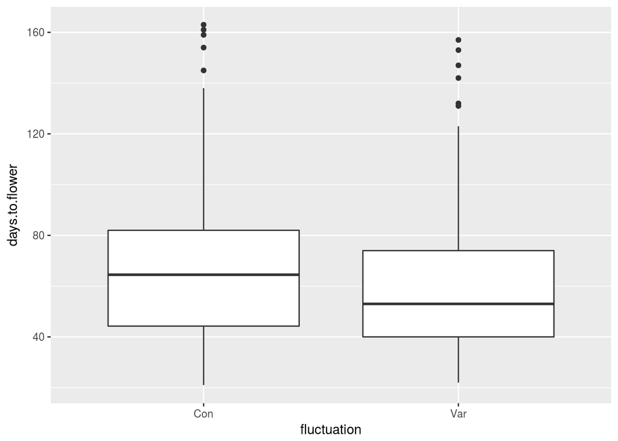

```r
expt1 %>%
  filter(vernalization == "V") %>%
  ggplot(aes(fluctuation, days.to.flower)) +
  geom_boxplot()
```

> **Challenge:** Can you make a violin plot of the days to flower for the different genotypes that have been growing in short days (8h light)?

### Summarise data with `group_by` and `summarise`

Sometimes we might want to summarise our data into a smaller table.

This kind of operation can be achieved by combining two `dplyr` functions: `group_by()` and `summarise()`. Please note, grouping with `group_by()` doesn’t change how the data looks (apart from listing how it’s grouped). We can then do summaries based on those groupings with `summarise()`.

For example, we can summarise the mean flowering time for each genotype:

```r
expt1 %>%
  group_by(genotype) %>%
  summarise(mean.days.to.flower = mean(days.to.flower, na.rm = TRUE))
```

```
## # A tibble: 10 x 2
##      genotype mean.days.to.flower
##         <chr>               <dbl>
##  1    Col Ama            55.82836
##  2    Col FRI            70.19167
##  3      fca-6            70.45000
##  4  flc-3 FRI            53.13333
##  5      flk-1            77.55769
##  6      fve-3            81.25000
##  7       ld-1            89.76471
##  8      Ler-1            55.64706
##  9  prmt5 FRI            88.67925
## 10 vin3-4 FRI            95.67000
```

You can see that the output contains two columns: `genotype`, which was the column used to “group” the original table and `mean.days.to.flower`, which was the column we created with the `summarise` function. And there’s only 10 rows of this new table, which corresponds to one row for each genotype.

You can group the table by more than one variable, and you can also make more than one summary operation on the table. For example, we might want to calculate both the mean, median and standard deviation of the days to flower of each genotype grown in long and short days:

```r
expt1 %>%
  group_by(genotype, day.length) %>%
  summarise(mean.days.flower = mean(days.to.flower, na.rm = TRUE),
            sd.days.flower = sd(days.to.flower, na.rm = TRUE),
            median.days.flower = median(days.to.flower, na.rm = TRUE))
```

```
## # A tibble: 20 x 5
## # Groups:   genotype [?]
##      genotype day.length mean.days.flower sd.days.flower
##         <chr>      <int>            <dbl>          <dbl>
##  1    Col Ama          8         75.75714      17.434295
##  2    Col Ama         16         34.03125       8.801098
##  3    Col FRI          8         90.63158      23.835471
##  4    Col FRI         16         51.69841      17.660449
##  5      fca-6          8         97.03571      17.108547
##  6      fca-6         16         47.18750      10.007860
##  7  flc-3 FRI          8         71.45070      17.647977
##  8  flc-3 FRI         16         32.81250       8.840518
##  9      flk-1          8        113.52381       8.133997
## 10      flk-1         16         53.19355       8.510462
## 11      fve-3          8        121.31250       7.913859
## 12      fve-3         16         61.21875      10.941883
## 13       ld-1          8        130.57895      10.905227
## 14       ld-1         16         65.53125      11.199033
## 15      Ler-1          8         72.88889      16.890873
## 16      Ler-1         16         36.25000      10.267393
## 17  prmt5 FRI          8        106.29787      23.934616
## 18  prmt5 FRI         16         74.64407      25.953382
## 19 vin3-4 FRI          8        142.00000      23.666603
## 20 vin3-4 FRI         16         67.27419      13.880248
## # ... with 1 more variables: median.days.flower <dbl>
```

Now, you can see there’s 20 rows in that table. This is because we have one row for each combination of genotype (there’s 10 of them) and day.length (8h and 16h).

It is often useful to find how many observations we have for each group.

In the example above, let’s say we wanted to know how many plants we have of each genotype. For this we can use the special function `n()`, which will count the number of rows of each group in the original table:

```r
expt1 %>%
  group_by(genotype) %>%
  summarise(mean.days.to.flower = mean(days.to.flower, na.rm = TRUE),
            n.obs = n())
```

```
## # A tibble: 10 x 3
##      genotype mean.days.to.flower n.obs
##         <chr>               <dbl> <int>
##  1    Col Ama            55.82836   135
##  2    Col FRI            70.19167   128
##  3      fca-6            70.45000    64
##  4  flc-3 FRI            53.13333   136
##  5      flk-1            77.55769    60
##  6      fve-3            81.25000    60
##  7       ld-1            89.76471    60
##  8      Ler-1            55.64706    68
##  9  prmt5 FRI            88.67925   125
## 10 vin3-4 FRI            95.67000   121
```

Please note, you can use `n()` only inside `summarise()` function. There is a similar function, `count()` that can be used independently and piped in. Because counting the number of observations in a group is such a common operation, there’s actually a special function, `count()` just to do that one thing:

```r
expt1 %>%
  count(genotype, day.length)
```

```
## # A tibble: 20 x 3
##      genotype day.length     n
##         <chr>      <int> <int>
##  1    Col Ama          8    71
##  2    Col Ama         16    64
##  3    Col FRI          8    64
##  4    Col FRI         16    64
##  5      fca-6          8    32
##  6      fca-6         16    32
##  7  flc-3 FRI          8    72
##  8  flc-3 FRI         16    64
##  9      flk-1          8    28
## 10      flk-1         16    32
## 11      fve-3          8    28
## 12      fve-3         16    32
## 13       ld-1          8    28
## 14       ld-1         16    32
## 15      Ler-1          8    36
## 16      Ler-1         16    32
## 17  prmt5 FRI          8    61
## 18  prmt5 FRI         16    64
## 19 vin3-4 FRI          8    57
## 20 vin3-4 FRI         16    64
```

Often, we want to apply the same set of summary functions to several variables. For example, in our dataset we might want to group the data by genotype and treatment groups and then calculate the mean and standard deviation for all the traits measured. This kind of operation can be achieved using the `summarise_at` function.

Here is how it works:

```r
# Summarise all traits by treatment groups and genotype
expt1 %>%
  group_by(genotype, background, temperature, fluctuation, day.length, vernalization) %>%
  summarise_at(vars(days.to.bolt, days.to.flower, rosette.leaf.num, cauline.leaf.num, blade.length.mm, total.leaf.length.mm, blade.ratio),
               funs(mean, sd)) %>%
  ungroup()
```

```
## # A tibble: 120 x 20
##    genotype background temperature fluctuation day.length vernalization
##       <chr>      <chr>       <int>       <chr>      <int>         <chr>
##  1  Col Ama        Col          12         Con          8            NV
##  2  Col Ama        Col          12         Con          8             V
##  3  Col Ama        Col          12         Con         16            NV
##  4  Col Ama        Col          12         Con         16             V
##  5  Col Ama        Col          12         Var          8            NV
##  6  Col Ama        Col          12         Var          8             V
##  7  Col Ama        Col          12         Var         16            NV
##  8  Col Ama        Col          12         Var         16             V
##  9  Col Ama        Col          22         Con          8            NV
## 10  Col Ama        Col          22         Con          8             V
## # ... with 110 more rows, and 14 more variables: days.to.bolt_mean <dbl>,
## #   days.to.flower_mean <dbl>, rosette.leaf.num_mean <dbl>,
## #   cauline.leaf.num_mean <dbl>, blade.length.mm_mean <dbl>,
## #   total.leaf.length.mm_mean <dbl>, blade.ratio_mean <dbl>,
## #   days.to.bolt_sd <dbl>, days.to.flower_sd <dbl>,
## #   rosette.leaf.num_sd <dbl>, cauline.leaf.num_sd <dbl>,
## #   blade.length.mm_sd <dbl>, total.leaf.length.mm_sd <dbl>,
## #   blade.ratio_sd <dbl>
```

**Note:** It is important to say that, after you use the `group_by()` function, the table remains grouped by the variables you defined. This means that any operations you do afterwards will use this grouping, which might not be desirable! There is a function called `ungroup()`, which is usually good to use after you finish your operations.

### Saving data to a file

Once we have modified our data we might want to save it to come back to it later. For this we can use the function `write_csv()`

Let’s say that we were to remove some missing data from our data to share it with a collaborator (or later use in R ourselves):

```r
expt1.blade.ratio.clean <- expt1 %>%
  filter(!is.na(blade.ratio))

#alternatively, we can use drop_na() function that we used in the module02:
expt1.blade.ratio.clean2 <- expt1 %>% drop_na(blade.ratio)

write_csv(expt1.blade.ratio.clean, path = "../data/expt1_blade_ratio_clean.csv")
```

### Some key points to remember

- `dplyr` has many many useful functions to manipulate tables
- `dplyr` functions can be “chained” together using the `%>%` pipe
- We can save tables to text-based files using the `write_*` family of functions

### Futher reading and additional resources:

- [dplyr cheat sheet](https://www.rstudio.com/wp-content/uploads/2015/02/data-wrangling-cheatsheet.pdf)
- [data transformation chapter from ‘R for Data Science’](http://r4ds.had.co.nz/transform.html)